# R Notebook

# Customer Segmentation Group work

## Instructions

- Imagine you and your team mates have just founded a Data Science start up. Your first customer is a fundraising organization asking for support with regard to making most of their donor and transaction data.
- The Head of Fund Development who is your direct counterpart and project sponsor asks your team to come up with a segmentation of the donor base as quickly as possible. The manager has a basic understanding of RFM modelling and tells you that there was a simple model in use some years ago which was neither updated nor further developed.
- In general, your client organization is model-agnostic and trusts your judgment and consulting. However, the let you know that seeing alternative approaches in action together with your reflection, expertise and concluding recommendation how to process would be great …
- The clients finally provide you with a flat file together with a list of feature descriptions …

### Tasks

- Form a group of 3 to 4 persons
- Get accustomed to the data and have an explorative look at it.
- Think your variables that might be added to or derived from the dataset with relative ease, e.g. conducting some research, data enrichment etc.
- Take those down and formulate recommendations towards the client.
- If you find time and a viable data source, you may of course go ahead and enrich the dataset
- Apply at least two customer segmentation approaches to the provided data
- Model examples: RFM, k-Means-Algorithm
- Summarize the segmentation generated results and derived insights
- Compare the model outputs and formulate a recommendation for the customer

### Expected Output

- Deliverable: Pitch presentation
- Deadline: December 17th, 2021

## Prepro

```r
library(tidyverse)
```

```r
feature_description_original <- readxl::read_excel(
  "data/feature_description.xlsx")
feature_description_original
```

| Customer Number | Unique Identifier of Donor |
| --- | --- |
| Gender | Gender of person |
| Date of Birth | Customer´s date of birth (dd.mm.yyyy) |
| Postcode | Postal code (Austria) |
| COUNT2015 | Sporadic Donation Frequency 2015 |
| SUM2015 | Sporadic Donation Sum 2015 |
| MERCHANDISE2015 | Has customer made at least one purchase in merchandising store in 2015? |
| COUNT2016 | Sporadic Donation Frequency 2016 |
| SUM2016 | Sporadic Donation Sum 2016 |
| MERCHANDISE2016 | Has customer made at least one purchase in merchandising store in 2016? |
| COUNT2017 | Sporadic Donation Frequency 2017 |

[output cut: 10 more lines]

```r
customer_segmentation_raw <- read_csv2(
  "data/customer_segmentation_test.csv",
  col_types = list(col_character(), col_character(), col_character(), col_character(),
                col_double(), col_double(), col_character(), col_double(), col_double(),
                col_character(), col_double(), col_double(), col_character(), col_double(),
                col_double(), col_character(), col_double(), col_double(), col_character(),
                col_character(), col_character()),
  guess_max = 400000
) %>% mutate(
  `Date of Birth` = lubridate::dmy(`Date of Birth`),
  Gender = as.factor(Gender),
  MERCHANDISE2015 = as.factor(MERCHANDISE2015),
  MERCHANDISE2016 = as.factor(MERCHANDISE2016),
  MERCHANDISE2017 = as.factor(MERCHANDIESE2017),
  MERCHANDISE2018 = as.factor(MERCHANDIESE2018),
  MERCHANDISE2019 = as.factor(MERCHANDISE2019),
  LastPaymentDate = lubridate::dmy(LastPaymentDate),
  PenultimatePaymentDate = lubridate::dmy(PenultimatePaymentDate)
) %>% select(-c(MERCHANDIESE2017, MERCHANDIESE2018)) %>%
  rename(DateOfBirth = `Date of Birth`,
         ID =`Customer Number`)
```

```
i Using "','" as decimal and "'.'" as grouping mark. Use `read_delim()` for more control.
```

```r
skimr::skim(customer_segmentation_raw)
```

```
-- Data Summary ------------------------
                           Values
Name                       customer_segmentation_raw
Number of rows             406734
Number of columns          21
_______________________
Column type frequency:
  character                2
  Date                     3
  factor                   6
  numeric                  10
________________________
Group variables            None

-- Variable type: character -----------------------------------------------------------------------------------------------
# A tibble: 2 x 8
  skim_variable n_missing complete_rate   min   max empty n_unique whitespace
* <chr>             <int>         <dbl> <int> <int> <int>    <int>      <int>
1 ID                    0         1        10    10     0   406734          0
2 Postcode           9176         0.977     1     9     0     2982          0

-- Variable type: Date ----------------------------------------------------------------------------------------------------
# A tibble: 3 x 7
  skim_variable          n_missing complete_rate min        max        median     n_unique
* <chr>                      <int>         <dbl> <date>     <date>     <date>        <int>
1 DateOfBirth               155491         0.618 1902-04-21 2015-03-30 1948-03-09    25514
2 LastPaymentDate                0         1     2015-01-03 2020-02-13 2018-12-06     1361
3 PenultimatePaymentDate     44699         0.890 1995-12-31 2020-02-05 2017-04-12     5376

-- Variable type: factor --------------------------------------------------------------------------------------------------
# A tibble: 6 x 6
  skim_variable   n_missing complete_rate ordered n_unique top_counts
* <chr>               <int>         <dbl> <lgl>      <int> <chr>
1 Gender                  0             1 FALSE          3 fem: 203904, mal: 183467, fam: 19363
2 MERCHANDISE2015         0             1 FALSE          2 0: 401845, 1: 4889
3 MERCHANDISE2016         0             1 FALSE          2 0: 401585, 1: 5149
4 MERCHANDISE2019         0             1 FALSE          2 0: 401470, 1: 5264
5 MERCHANDISE2017         0             1 FALSE          2 0: 402378, 1: 4356
6 MERCHANDISE2018         0             1 FALSE          2 0: 401470, 1: 5264

-- Variable type: numeric -------------------------------------------------------------------------------------------------
# A tibble: 10 x 11
   skim_variable n_missing complete_rate   mean      sd    p0   p25   p50   p75     p100 hist
 * <chr>             <int>         <dbl>  <dbl>   <dbl> <dbl> <dbl> <dbl> <dbl>    <dbl> <chr>
 1 COUNT2015             0             1  2.52     4.00     0     0     2     2      96  ▇▁▁▁▁
 2 SUM2015               0             1 42.4    850.       0     0    15    45  388114. ▇▁▁▁▁
 3 COUNT2016             0             1  1.22     2.02     0     0     1     1     178  ▇▁▁▁▁
 4 SUM2016               0             1 50.9    591.       0     0    16    50  295600. ▇▁▁▁▁
 5 COUNT2017             0             1  1.06     1.91     0     0     0     1      95  ▇▁▁▁▁
 6 SUM2017               0             1 24.8    573.       0     0     0    20  207135. ▇▁▁▁▁
 7 COUNT2018             0             1  1.00     1.87     0     0     0     1      49  ▇▁▁▁▁
 8 SUM2018               0             1 20.6   1553.       0     0     0    15  911146. ▇▁▁▁▁
 9 COUNT2019             0             1  0.966    1.79     0     0     0     1      31  ▇▁▁▁▁
10 SUM2019               0             1 46.4   4000.       0     0     0    30 2400000  ▇▁▁▁▁
```

### feature engineering

Bin hier sehr offen für Verbesserungsvorschläge ^^

```r
zip_code_list <- readxl::read_excel("data/PLZ_Verzeichnis-20211201.xls")
zip_code_list
```

| PLZ | Ort | Bundesland | gültig ab | gültig bis | NamePLZTyp | intern_extern | adressierbar | Postfach |
| --- | --- | --- | --- | --- | --- | --- | --- | --- |
| 1000 | Wien | W | 01.08.2009 | NA | PLZ-Postfach | extern | Nein | Ja |
| 1004 | Wien | W | 01.01.1966 | NA | InteressentenPLZ | extern | Nein | Ja |
| 1006 | Wien | W | 01.02.2015 | NA | PLZ-Postfach | extern | Nein | Ja |
| 1010 | Wien | W | 01.01.1966 | NA | PLZ-Adressierung | extern | Ja | Ja |
| 1011 | Wien Postfach | W | 01.01.1966 | NA | PLZ-Postfach | extern | Nein | Ja |
| 1015 | Wien | W | 01.01.1966 | NA | PLZ-Postfach | extern | Nein | Ja |
| 1016 | Wien | W | 01.01.1966 | NA | PLZ-Postfach | extern | Nein | Ja |
| 1017 | Wien-Parlament | W | 22.04.2015 | NA | InteressentenPLZ | extern | Nein | Ja |
| 1020 | Wien | W | 01.01.1966 | NA | PLZ-Adressierung | extern | Ja | Ja |
| 1021 | Wien Postfach | W | 01.01.1966 | NA | PLZ-Postfach | extern | Nein | Ja |

[output cut: 990 more lines]

```r
customer_segmentation_with_zip <- customer_segmentation_raw %>%
  left_join(zip_code_list, by = c("Postcode" = "PLZ")) %>%
  select(-c(`gültig ab`, `gültig bis`, NamePLZTyp, intern_extern, adressierbar, Postfach)) %>%
  drop_na(Postcode, Ort, Bundesland) %>%
  mutate(Postcode = as.factor(Postcode),
         Bundesland = as.factor(Bundesland))

customer_segmentation_with_zip
```

| ID | Gender | DateOfBirth | Postcode | COUNT2015 | SUM2015 | MERCHANDISE2015 | COUNT2016 | SUM2016 | MERCHANDISE2016 | COUNT2017 | SUM2017 | COUNT2018 | SUM2018 | COUNT2019 | SUM2019 | MERCHANDISE2019 | LastPaymentDate | PenultimatePaymentDate | MERCHANDISE2017 | MERCHANDISE2018 | Ort | Bundesland |
| --- | --- | --- | --- | --- | --- | --- | --- | --- | --- | --- | --- | --- | --- | --- | --- | --- | --- | --- | --- | --- | --- | --- |
| 0000002073 | female |  | 1000 | 2 | 45.000 | 0 | 0 | 0.00 | 0 | 0 | 0.00 | 0 | 0.000 | 0 | 0.000 | 0 | 2015-05-05 |  | 0 | 0 | Wien | W |
| 0000002074 | female |  | 1010 | 0 | 0.000 | 0 | 0 | 0.00 | 0 | 0 | 0.00 | 0 | 0.000 | 1 | 15.000 | 0 | 2019-11-13 | 2011-10-12 | 0 | 0 | Wien | W |
| 0000002077 | female |  | 1010 | 0 | 0.000 | 0 | 0 | 0.00 | 0 | 0 | 0.00 | 0 | 0.000 | 1 | 15.000 | 0 | 2019-11-16 |  | 0 | 0 | Wien | W |
| 0000002079 | female |  | 1010 | 0 | 0.000 | 0 | 0 | 0.00 | 0 | 0 | 0.00 | 0 | 0.000 | 1 | 15.000 | 0 | 2019-12-05 | 2010-10-14 | 0 | 0 | Wien | W |
| 0000002080 | female |  | 1010 | 0 | 0.000 | 0 | 0 | 0.00 | 0 | 0 | 0.00 | 0 | 0.000 | 1 | 22.500 | 0 | 2019-11-19 |  | 0 | 0 | Wien | W |
| 0000002082 | female |  | 1010 | 0 | 0.000 | 0 | 0 | 0.00 | 0 | 0 | 0.00 | 0 | 0.000 | 1 | 30.000 | 0 | 2019-10-02 | 2010-12-07 | 0 | 0 | Wien | W |
| 0000002084 | female |  | 1010 | 0 | 0.000 | 0 | 0 | 0.00 | 0 | 0 | 0.00 | 0 | 0.000 | 1 | 30.000 | 0 | 2019-12-11 |  | 0 | 0 | Wien | W |
| 0000002089 | female |  | 1010 | 0 | 0.000 | 0 | 0 | 0.00 | 0 | 0 | 0.00 | 0 | 0.000 | 1 | 45.000 | 0 | 2019-12-11 |  | 0 | 0 | Wien | W |
| 0000002094 | female |  | 1010 | 0 | 0.000 | 0 | 0 | 0.00 | 0 | 0 | 0.00 | 0 | 0.000 | 3 | 45.000 | 0 | 2020-01-03 | 2019-12-02 | 0 | 0 | Wien | W |
| 0000002096 | female |  | 1010 | 0 | 0.000 | 0 | 0 | 0.00 | 0 | 0 | 0.00 | 1 | 3.750 | 0 | 0.000 | 0 | 2018-12-05 |  | 0 | 0 | Wien | W |

[output cut: 990 more lines]

```r
# here we define, which months should be understood as "christmas months" to define "XMAS_donation"
XMAS_months = c(11,
                12,
                1)

# this date will be used as the reference for this analysis
reference_date <- lubridate::ymd("2021-12-17")

customer_segmentation_first_prepro <- customer_segmentation_with_zip %>%
  mutate(
    # year of customer's birthday
    year_born = lubridate::year(DateOfBirth),

    # age of donors at their last donation
    age_at_last_donation = lubridate::interval(DateOfBirth, LastPaymentDate) %>%
      as.numeric("years") %>%
      as.integer(),

    generation_moniker = case_when(
      year_born <= 1945 ~ "silent" ,
      year_born <= 1964 ~ "boomer",
      year_born <= 1980 ~ "x",
      year_born <= 1996 ~ "millennial",
      year_born <= 2012 ~ "z"
    ) %>% as_factor(),

    # total number of donations over all years
    COUNTtotal = COUNT2015+
                 COUNT2016+
                 COUNT2017+
                 COUNT2018+
                 COUNT2019,

    # total donation amount over all years
    SUMtotal = SUM2015+
               SUM2016+
               SUM2017+
               SUM2018+
               SUM2019,

    # average donation amount
    SUMaverage = SUMtotal / COUNTtotal,

    # month of the last payment
    LastPaymentMONTH = lubridate::month(LastPaymentDate) %>% as.factor(),

    # month of second to last payment
    PenultimatePaymentMONTH = lubridate::month(PenultimatePaymentDate) %>% as.factor(),

    # year of the last payment
    LastPaymentYEAR = lubridate::year(LastPaymentDate),

    # year of second to last payment
    PenultimatePaymentYEAR = lubridate::year(PenultimatePaymentDate),

    # THIS ONE NEEDS WORK
    # status as christmas donor if the last two payments were around christmas,
    # but we have to tweak the time interval (is Nov to Jan too large?)
    # also: what about people that only have one payment in total, that should be considered. The "maybe" status is shady at best
    XMAS_donor = as_factor(case_when(LastPaymentMONTH %in% XMAS_months & PenultimatePaymentMONTH %in% XMAS_months ~ "yes",
                                     LastPaymentMONTH %in% XMAS_months ~ "maybe",
                                     TRUE ~ "unlikely")),

    # days between last and second to last payment
    donation_interval = lubridate::day(lubridate::days(LastPaymentDate - PenultimatePaymentDate)),

    # days since the last payment in relation to our reference date
    days_since_last_payment = as.integer(LastPaymentDate - reference_date),

    # binary factor variable expressing if any merchandise was bought over the observation period (clumsily coded)
    merchandise_any = as_factor(if_else(
                                  !is.na(MERCHANDISE2015) & MERCHANDISE2015 != 0 |
                                  !is.na(MERCHANDISE2016) & MERCHANDISE2016 != 0 |
                                  !is.na(MERCHANDISE2017) & MERCHANDISE2017 != 0 |
                                  !is.na(MERCHANDISE2018) & MERCHANDISE2018 != 0 |
                                  !is.na(MERCHANDISE2019) & MERCHANDISE2019 != 0,
                                  1,
                                  0))) %>%

  # grouping for the next mutation (num_of_donation_years)
  group_by(ID) %>%

  # number of years in which anything was donated (0-5)
  mutate(num_of_donation_years = sum(COUNT2015 > 0,
                                     COUNT2016 > 0,
                                     COUNT2017 > 0,
                                     COUNT2018 > 0,
                                     COUNT2019 > 0, na.rm=T)) %>%

  # ungrouping is important! ;)
  # I learned that skimr tries to show its output based on groups if working with a grouped dataset... that crashed my computer twice ^^
  ungroup() %>%

  # remove variables that have no further use or
  select(-c(ID, DateOfBirth, LastPaymentDate, PenultimatePaymentDate))
```

```r
customer_segmentation_first_prepro
```

| Gender | Postcode | COUNT2015 | SUM2015 | MERCHANDISE2015 | COUNT2016 | SUM2016 | MERCHANDISE2016 | COUNT2017 | SUM2017 | COUNT2018 | SUM2018 | COUNT2019 | SUM2019 | MERCHANDISE2019 | MERCHANDISE2017 | MERCHANDISE2018 | Ort | Bundesland | year_born | age_at_last_donation | generation_moniker | COUNTtotal | SUMtotal | SUMaverage | LastPaymentMONTH | PenultimatePaymentMONTH | LastPaymentYEAR | PenultimatePaymentYEAR | XMAS_donor | … |
| --- | --- | --- | --- | --- | --- | --- | --- | --- | --- | --- | --- | --- | --- | --- | --- | --- | --- | --- | --- | --- | --- | --- | --- | --- | --- | --- | --- | --- | --- | --- |
| female | 1000 | 2 | 45.000 | 0 | 0 | 0.00 | 0 | 0 | 0.00 | 0 | 0.000 | 0 | 0.000 | 0 | 0 | 0 | Wien | W | NA | NA | NA | 2 | 45.000 | 22.500000 | 5 | NA | 2015 | NA | unlikely | … |
| female | 1010 | 0 | 0.000 | 0 | 0 | 0.00 | 0 | 0 | 0.00 | 0 | 0.000 | 1 | 15.000 | 0 | 0 | 0 | Wien | W | NA | NA | NA | 1 | 15.000 | 15.000000 | 11 | 10 | 2019 | 2011 | maybe | … |
| female | 1010 | 0 | 0.000 | 0 | 0 | 0.00 | 0 | 0 | 0.00 | 0 | 0.000 | 1 | 15.000 | 0 | 0 | 0 | Wien | W | NA | NA | NA | 1 | 15.000 | 15.000000 | 11 | NA | 2019 | NA | maybe | … |
| female | 1010 | 0 | 0.000 | 0 | 0 | 0.00 | 0 | 0 | 0.00 | 0 | 0.000 | 1 | 15.000 | 0 | 0 | 0 | Wien | W | NA | NA | NA | 1 | 15.000 | 15.000000 | 12 | 10 | 2019 | 2010 | maybe | … |
| female | 1010 | 0 | 0.000 | 0 | 0 | 0.00 | 0 | 0 | 0.00 | 0 | 0.000 | 1 | 22.500 | 0 | 0 | 0 | Wien | W | NA | NA | NA | 1 | 22.500 | 22.500000 | 11 | NA | 2019 | NA | maybe | … |
| female | 1010 | 0 | 0.000 | 0 | 0 | 0.00 | 0 | 0 | 0.00 | 0 | 0.000 | 1 | 30.000 | 0 | 0 | 0 | Wien | W | NA | NA | NA | 1 | 30.000 | 30.000000 | 10 | 12 | 2019 | 2010 | unlikely | … |
| female | 1010 | 0 | 0.000 | 0 | 0 | 0.00 | 0 | 0 | 0.00 | 0 | 0.000 | 1 | 30.000 | 0 | 0 | 0 | Wien | W | NA | NA | NA | 1 | 30.000 | 30.000000 | 12 | NA | 2019 | NA | maybe | … |
| female | 1010 | 0 | 0.000 | 0 | 0 | 0.00 | 0 | 0 | 0.00 | 0 | 0.000 | 1 | 45.000 | 0 | 0 | 0 | Wien | W | NA | NA | NA | 1 | 45.000 | 45.000000 | 12 | NA | 2019 | NA | maybe | … |
| female | 1010 | 0 | 0.000 | 0 | 0 | 0.00 | 0 | 0 | 0.00 | 0 | 0.000 | 3 | 45.000 | 0 | 0 | 0 | Wien | W | NA | NA | NA | 3 | 45.000 | 15.000000 | 1 | 12 | 2020 | 2019 | yes | … |
| female | 1010 | 0 | 0.000 | 0 | 0 | 0.00 | 0 | 0 | 0.00 | 1 | 3.750 | 0 | 0.000 | 0 | 0 | 0 | Wien | W | NA | NA | NA | 1 | 3.750 | 3.750000 | 12 | NA | 2018 | NA | maybe | … |

[output cut: 990 more lines]

```r
customer_segmentation_first_prepro %>% skimr::skim()
```

```
-- Data Summary ------------------------
                           Values
Name                       Piped data
Number of rows             396694
Number of columns          34
_______________________
Column type frequency:
  character                1
  factor                   13
  numeric                  20
________________________
Group variables            None

-- Variable type: character -----------------------------------------------------------------------------------------------
# A tibble: 1 x 8
  skim_variable n_missing complete_rate   min   max empty n_unique whitespace
* <chr>             <int>         <dbl> <int> <int> <int>    <int>      <int>
1 Ort                   0             1     2    40     0     2178          0

-- Variable type: factor --------------------------------------------------------------------------------------------------
# A tibble: 13 x 6
   skim_variable           n_missing complete_rate ordered n_unique top_counts
 * <chr>                       <int>         <dbl> <lgl>      <int> <chr>
 1 Gender                          0         1     FALSE          3 fem: 199545, mal: 179215, fam: 17934
 2 Postcode                        0         1     FALSE       2249 122: 6776, 121: 6208, 110: 5941, 502: 5383
 3 MERCHANDISE2015                 0         1     FALSE          2 0: 391818, 1: 4876
 4 MERCHANDISE2016                 0         1     FALSE          2 0: 391552, 1: 5142
 5 MERCHANDISE2019                 0         1     FALSE          2 0: 391460, 1: 5234
 6 MERCHANDISE2017                 0         1     FALSE          2 0: 392339, 1: 4355
 7 MERCHANDISE2018                 0         1     FALSE          2 0: 391460, 1: 5234
 8 Bundesland                      0         1     FALSE          9 N: 88175, W: 70706, O: 66082, St: 57348
 9 generation_moniker         146208         0.631 FALSE          5 sil: 110508, boo: 102068, x: 33020, mil: 4734
10 LastPaymentMONTH                0         1     FALSE         12 12: 119035, 11: 66379, 1: 45775, 10: 42275
11 PenultimatePaymentMONTH     37875         0.905 FALSE         12 12: 91203, 11: 56900, 10: 42674, 1: 27463
12 XMAS_donor                      0         1     FALSE          3 unl: 165505, may: 119746, yes: 111443
13 merchandise_any                 0         1     FALSE          2 0: 377620, 1: 19074

-- Variable type: numeric -------------------------------------------------------------------------------------------------
# A tibble: 20 x 11
   skim_variable           n_missing complete_rate      mean      sd         p0     p25     p50    p75     p100 hist
 * <chr>                       <int>         <dbl>     <dbl>   <dbl>      <dbl>   <dbl>   <dbl>  <dbl>    <dbl> <chr>
 1 COUNT2015                       0         1         2.56     4.03     0          0       2      4        96  ▇▁▁▁▁
 2 SUM2015                         0         1        41.1    724.       0          0      15     45    388114. ▇▁▁▁▁
 3 COUNT2016                       0         1         1.24     2.03     0          0       1      1       178  ▇▁▁▁▁
 4 SUM2016                         0         1        51.2    597.       0          0      20     50    295600. ▇▁▁▁▁
 5 COUNT2017                       0         1         1.08     1.92     0          0       0      1        95  ▇▁▁▁▁
 6 SUM2017                         0         1        24.5    485.       0          0       0     20    207135. ▇▁▁▁▁
 7 COUNT2018                       0         1         1.02     1.88     0          0       0      1        49  ▇▁▁▁▁
 8 SUM2018                         0         1        20.8   1571.       0          0       0     15    911146. ▇▁▁▁▁
 9 COUNT2019                       0         1         0.984    1.80     0          0       0      1        31  ▇▁▁▁▁
10 SUM2019                         0         1        46.9   4050.       0          0       0     30   2400000  ▇▁▁▁▁
11 year_born                  146204         0.631  1949.      14.0   1902       1939    1948   1959      2015  ▁▇▇▂▁
12 age_at_last_donation       146204         0.631    68.3     14.0      0         59      70     79       117  ▁▁▇▇▁
13 COUNTtotal                      0         1         6.87     9.93     1          2       3      7       273  ▇▁▁▁▁
14 SUMtotal                        0         1       184.    4899.       0.0075    30      65    160   2400225  ▇▁▁▁▁
15 SUMaverage                      0         1        36.1   1531.       0.0075    11.2    17.3   29.4  750000  ▇▁▁▁▁
16 LastPaymentYEAR                 0         1      2018.       1.53  2015       2016    2018   2019      2020  ▅▂▃▇▂
17 PenultimatePaymentYEAR      37875         0.905  2016.       3.91  1995       2015    2017   2018      2020  ▁▁▁▃▇
18 donation_interval           37875         0.905   774.    1216.       1        123     354    762      8766  ▇▁▁▁▁
19 days_since_last_payment         0         1     -1293.     561.   -2540      -1814   -1102   -762      -673  ▂▂▂▃▇
20 num_of_donation_years           0         1         2.50     1.49     1          1       2      4         5  ▇▅▃▂▃
```

```r
#Maybe it's a good idea to take out all the NAs for age. Obviously we lose a lot of rows, but 251000 left still seems plenty to me.
customer_segmentation_complete <- customer_segmentation_first_prepro %>% drop_na(year_born)
customer_segmentation_complete
```

| Gender | Postcode | COUNT2015 | SUM2015 | MERCHANDISE2015 | COUNT2016 | SUM2016 | MERCHANDISE2016 | COUNT2017 | SUM2017 | COUNT2018 | SUM2018 | COUNT2019 | SUM2019 | MERCHANDISE2019 | MERCHANDISE2017 | MERCHANDISE2018 | Ort | Bundesland | year_born | age_at_last_donation | generation_moniker | COUNTtotal | SUMtotal | SUMaverage | LastPaymentMONTH | PenultimatePaymentMONTH | LastPaymentYEAR | PenultimatePaymentYEAR | XMAS_donor | … |
| --- | --- | --- | --- | --- | --- | --- | --- | --- | --- | --- | --- | --- | --- | --- | --- | --- | --- | --- | --- | --- | --- | --- | --- | --- | --- | --- | --- | --- | --- | --- |
| female | 1060 | 2 | 15.000 | 0 | 0 | 0.00 | 0 | 0 | 0.00 | 0 | 0.0000 | 1 | 15.000 | 0 | 0 | 0 | Wien | W | 1911 | 108 | silent | 3 | 30.0000 | 10.000000 | 6 | 2 | 2019 | 2015 | unlikely | … |
| female | 1210 | 2 | 45.000 | 0 | 1 | 60.00 | 0 | 0 | 0.00 | 0 | 0.0000 | 0 | 0.000 | 0 | 0 | 0 | Wien | W | 1913 | 103 | silent | 3 | 105.0000 | 35.000000 | 4 | 3 | 2016 | 2015 | unlikely | … |
| female | 4600 | 2 | 7.500 | 0 | 0 | 0.00 | 0 | 0 | 0.00 | 0 | 0.0000 | 0 | 0.000 | 0 | 0 | 0 | Wels | O | 1913 | 101 | silent | 2 | 7.5000 | 3.750000 | 5 | 12 | 2015 | 2011 | unlikely | … |
| female | 3430 | 10 | 90.825 | 0 | 3 | 90.00 | 0 | 1 | 1.50 | 3 | 31.5000 | 0 | 0.000 | 0 | 0 | 0 | Tulln an der Donau | N | 1913 | 104 | silent | 17 | 213.8250 | 12.577941 | 2 | 1 | 2018 | 2018 | unlikely | … |
| female | 1090 | 4 | 12.825 | 0 | 5 | 120.00 | 0 | 3 | 30.00 | 0 | 0.0000 | 0 | 0.000 | 0 | 0 | 0 | Wien | W | 1913 | 103 | silent | 12 | 162.8250 | 13.568750 | 7 | 4 | 2017 | 2017 | unlikely | … |
| female | 1030 | 4 | 45.000 | 0 | 0 | 0.00 | 0 | 0 | 0.00 | 0 | 0.0000 | 0 | 0.000 | 0 | 0 | 0 | Wien | W | 1913 | 101 | silent | 4 | 45.0000 | 11.250000 | 5 | 2 | 2015 | 2015 | unlikely | … |
| female | 1070 | 0 | 0.000 | 0 | 0 | 0.00 | 0 | 0 | 0.00 | 1 | 22.5000 | 1 | 45.000 | 0 | 0 | 0 | Wien | W | 1914 | 105 | silent | 2 | 67.5000 | 33.750000 | 10 | 12 | 2019 | 2018 | unlikely | … |
| female | 3910 | 2 | 30.000 | 0 | 0 | 0.00 | 0 | 0 | 0.00 | 0 | 0.0000 | 0 | 0.000 | 0 | 0 | 0 | Zwettl | N | 1914 | 101 | silent | 2 | 30.0000 | 15.000000 | 10 | 10 | 2015 | 2014 | unlikely | … |
| female | 1090 | 2 | 15.000 | 0 | 0 | 0.00 | 0 | 0 | 0.00 | 0 | 0.0000 | 0 | 0.000 | 0 | 0 | 0 | Wien | W | 1914 | 100 | silent | 2 | 15.0000 | 7.500000 | 5 | 12 | 2015 | 2014 | unlikely | … |
| female | 8693 | 4 | 30.000 | 0 | 2 | 40.00 | 0 | 0 | 0.00 | 0 | 0.0000 | 0 | 0.000 | 0 | 0 | 0 | Mürzsteg | St | 1914 | 101 | silent | 6 | 70.0000 | 11.666667 | 2 | 1 | 2016 | 2016 | unlikely | … |

[output cut: 990 more lines]

### Visual Exploration

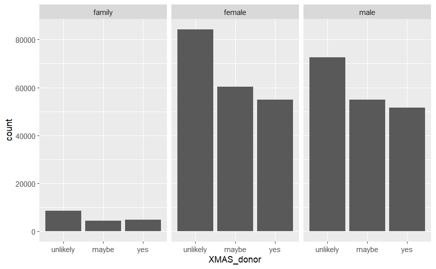

```r
ggplot(customer_segmentation_first_prepro, aes(XMAS_donor)) +
  geom_bar() +
  facet_wrap(~Gender)
```

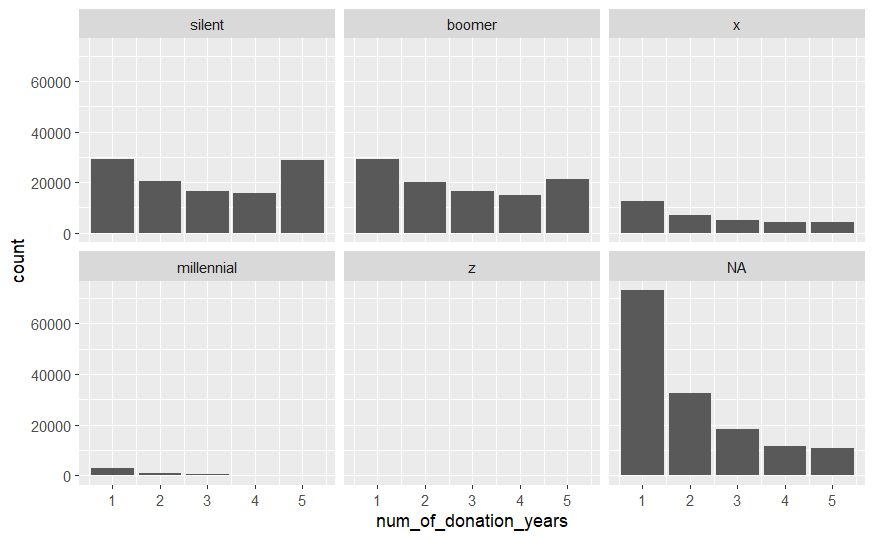

```r
ggplot(customer_segmentation_first_prepro, aes(num_of_donation_years)) +
  geom_bar() +
  facet_wrap(~generation_moniker)
```

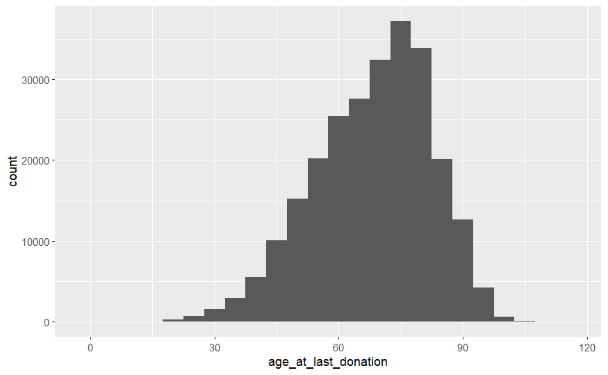

```r
ggplot(customer_segmentation_first_prepro %>% drop_na(age_at_last_donation), aes(age_at_last_donation)) +
  geom_histogram(binwidth = 5)
```

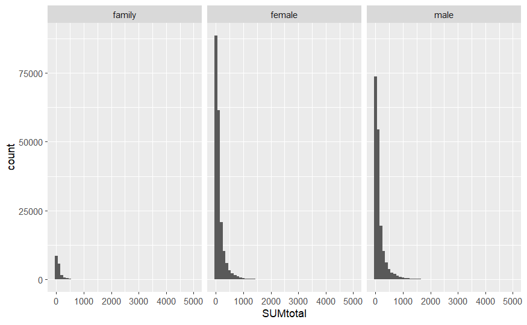

```r
ggplot(customer_segmentation_first_prepro %>% filter(SUMtotal > 0 & SUMtotal < 5000), aes(x = SUMtotal)) +
  geom_histogram(binwidth = 100) +
  facet_wrap(~Gender)
```

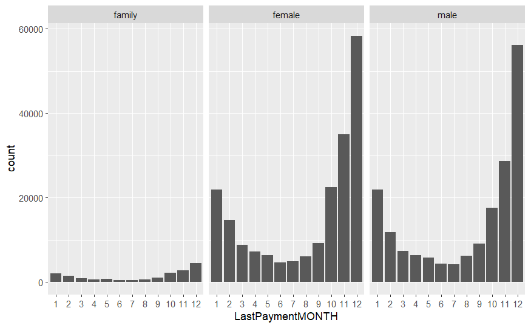

```r
ggplot(customer_segmentation_first_prepro, aes(LastPaymentMONTH)) +
  geom_bar() +
  facet_wrap(~Gender)
```

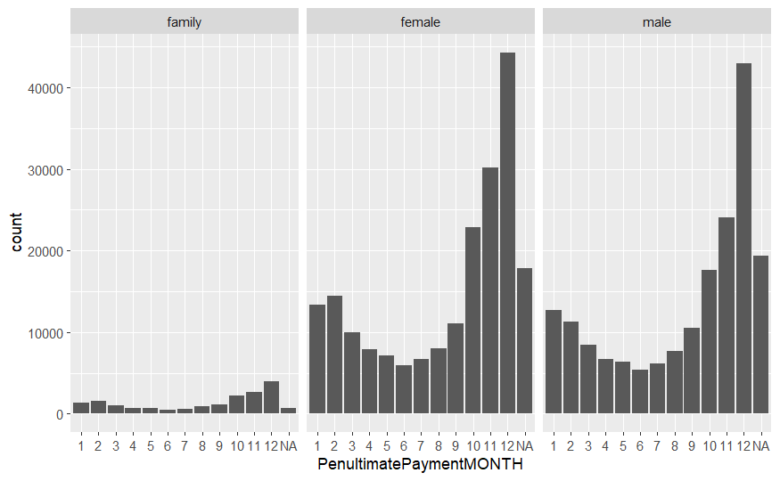

```r
ggplot(customer_segmentation_first_prepro, aes(PenultimatePaymentMONTH)) +
  geom_bar() +
  facet_wrap(~Gender)
```

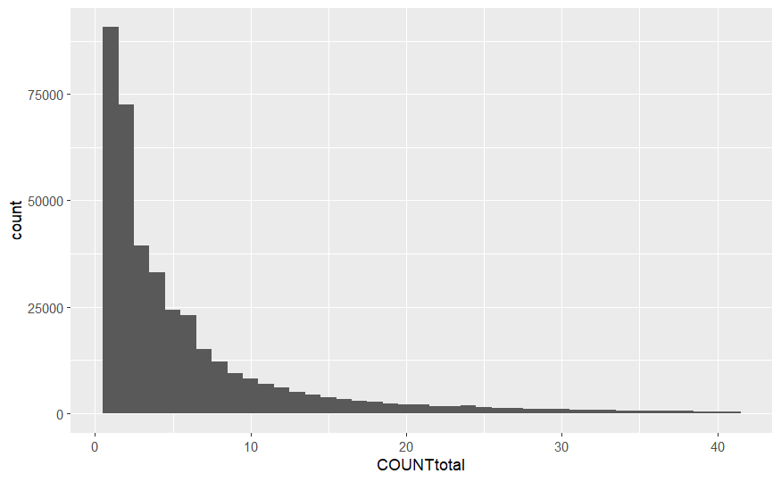

```r
ggplot(customer_segmentation_first_prepro %>% filter(COUNTtotal < (7 * 6)), aes(COUNTtotal)) +
  geom_histogram(binwidth = 1)
```

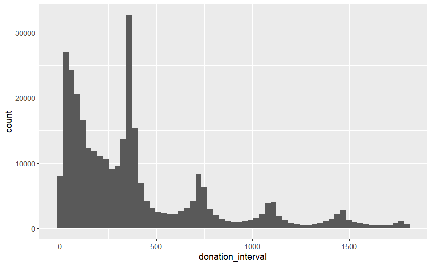

```r
ggplot(customer_segmentation_first_prepro %>% drop_na(donation_interval) %>% filter(donation_interval < (360 * 5)), aes(donation_interval)) +
  geom_histogram(binwidth = 30)
```

```r
mean_total_sum <- customer_segmentation_first_prepro$SUMtotal %>% mean(na.rm = TRUE)
sd_total_sum <- customer_segmentation_first_prepro$SUMtotal %>% sd(na.rm = TRUE)

ggplot(customer_segmentation_first_prepro %>% drop_na(year_born) %>% filter(SUMtotal < (mean_total_sum + sd_total_sum * 6)), aes(year_born, SUMtotal)) +
  geom_point(alpha = 1 / 10)
```

[output not shown]

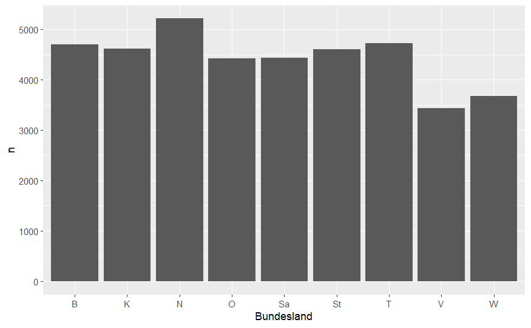

```r
# taken from https://de.statista.com/statistik/daten/studie/75396/umfrage/entwicklung-der-bevoelkerung-in-oesterreich-nach-bundesland-seit-1996/
pop_vienna <- 1921153
pop_lower_austria <- 1691040
pop_upper_austria <- 1495756
pop_styria <- 1247159
pop_tyrol <- 760161
pop_carithia <- 562230
pop_salzburg <- 560643
pop_vorarlberg <- 399164
pop_burgenland <- 296040

donors_per_state_per_100_000_inhabitants <- customer_segmentation_first_prepro %>%
  select(Bundesland) %>%
  group_by(Bundesland) %>%
  count() %>%
  ungroup() %>%
  mutate(
    n = case_when(
      Bundesland == "B" ~ n / pop_burgenland * 100000,
      Bundesland == "K" ~ n / pop_carithia * 100000,
      Bundesland == "N" ~ n / pop_lower_austria * 100000,
      Bundesland == "O" ~ n / pop_upper_austria * 100000,
      Bundesland == "Sa" ~ n / pop_salzburg * 100000,
      Bundesland == "St" ~ n / pop_styria * 100000,
      Bundesland == "T" ~ n / pop_tyrol * 100000,
      Bundesland == "V" ~ n / pop_vorarlberg * 100000,
      Bundesland == "W" ~ n / pop_vienna * 100000
    )
  )

ggplot(donors_per_state_per_100_000_inhabitants, aes(Bundesland, n)) +
  geom_col()
```

[figure not shown]

```r
ggplot(customer_segmentation_first_prepro, aes(days_since_last_payment)) +
  geom_histogram(binwidth = 30)
```

### RFM

RFM segments customers according to three variabless: Recency, Frequency, Monetary Value. Using the `rfm` package, RFM scores can be computed either on raw transaction data (one row per transaction), or on aggregated customer data (one row per customer). For the former, the function `rfm_table_order` can be used, for the latter either `rfm_table_customer` or `rfm_table_customer2`. Since our dataset represents aggregated customer data, the latter should be used. It can be computer directly from the raw data:

```r
library(rfm)

rfm_scores <- customer_segmentation_raw %>%
  # create new variables: total donation sum; total number of donations
  mutate(SUMtotal = SUM2015 + SUM2016 + SUM2017 + SUM2018 + SUM2019,
         COUNTtotal = COUNT2015 + COUNT2016 + COUNT2017 + COUNT2018 + COUNT2019,
         LastPaymentDate = as.Date(LastPaymentDate)) %>%
  # compute RFM scores
  rfm_table_customer_2(customer_id = ID,
                       n_transactions = COUNTtotal,
                       latest_visit_date = LastPaymentDate,
                       total_revenue = SUMtotal,
                       analysis_date = reference_date)

rfm_scores
```

| customer_id | recency_days | transaction_count | amount | recency_score | frequency_score | monetary_score | rfm_score |
| --- | --- | --- | --- | --- | --- | --- | --- |
| 0000000001 | 730 | 1 | 4.500 | 5 | 1 | 1 | 511 |
| 0000000002 | 720 | 1 | 1.530 | 5 | 1 | 1 | 511 |
| 0000000003 | 743 | 1 | 3.000 | 5 | 1 | 1 | 511 |
| 0000000004 | 927 | 1 | 4.500 | 4 | 1 | 1 | 411 |
| 0000000005 | 993 | 1 | 4.950 | 3 | 1 | 1 | 311 |
| 0000000006 | 1056 | 1 | 6.000 | 3 | 1 | 1 | 311 |
| 0000000007 | 1029 | 1 | 6.750 | 3 | 1 | 1 | 311 |
| 0000000008 | 925 | 1 | 7.500 | 4 | 1 | 1 | 411 |
| 0000000009 | 745 | 1 | 0.225 | 5 | 1 | 1 | 511 |
| 0000000010 | 1024 | 1 | 7.500 | 3 | 1 | 1 | 311 |

[output cut: 990 more lines]

Visual inspection of RFM scores:

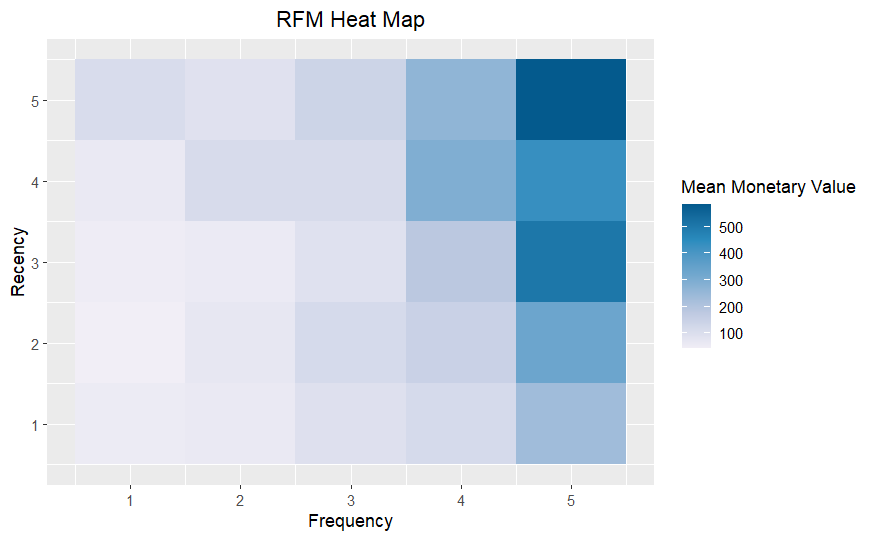

```r
rfm_heatmap(rfm_scores)
```

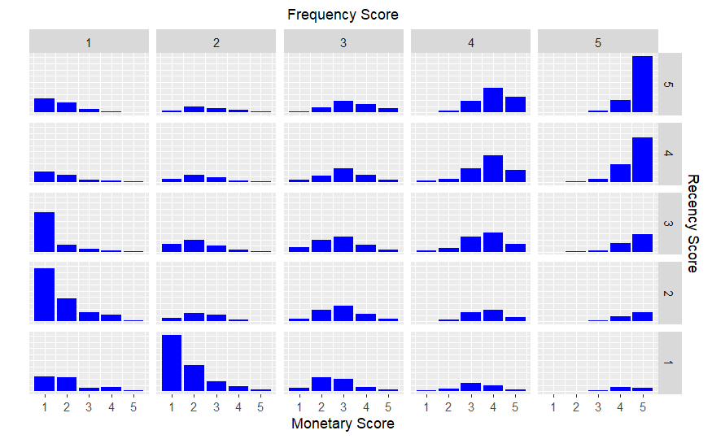

```r
rfm_bar_chart(rfm_scores)
```

In the frequency vs monetary value plot below there is no strong correlation between donation frequency and monetary value. However, in the low-frequency area, there seems to be a slight positive correlation with monetary value.

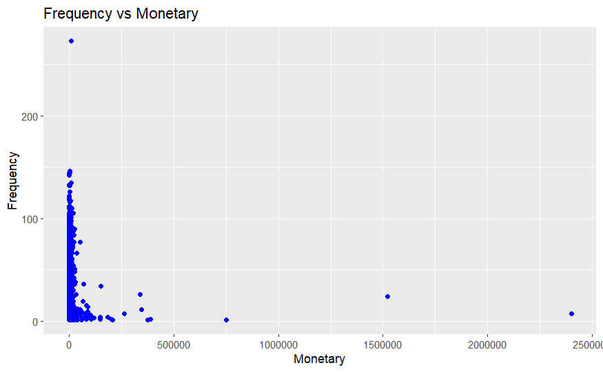

```r
rfm_fm_plot(rfm_scores)
```